# Tarea 1 - Leonel Atencio - DM

Este ejercicio se refiere al conjunto de datos College, que se puede encontrar en el archivo College.csv. Contiene una serie de variables para 777 diferentes universidades y escuelas superiores de los EE.UU.. Las variables son:

- Private: Indicador público / privado
- App: Número de solicitudes recibidas
- Accept: Número de solicitantes aceptados
- Enroll: Número de nuevos alumnos matriculados
- Top10 perc: Estudiantes nuevos correspondiente al diez por ciento superior del “high school”
- Top25 perc: Estudiantes nuevos correspondiente al veinticinco por ciento superior del “high school”
- F.Undergrad: Número de estudiantes de tiempo completo
- P.Undergrad: Número de estudiantes a tiempo parcial
- Room.Board: los costos de pensión
- Outstate: cantidad de estudiantes extranjeros.
- Books: los costos estimados de libros
- Personal: Se estima que el gasto personal
- Phd: Porcentaje de profesores con doctorados
- Terminal: Porcentaje de profesores con grado de terminales
- S.F.Ratio: Proporción de estudiantes / profesores
- perc.alumni: Porcentaje de alumnos que donan
- Expend: Los gastos de instrucción por estudiante
- Grad.Rate: Porcentaje de graduación

### Utilizar la función `read.csv ()` para leer los datos en R.

```r
library(readr)
College <- read_delim("../College.csv", ";", escape_double = FALSE, trim_ws = TRUE)
cols(
  X1 = col_character(),
  Private = col_character(),
  Apps = col_integer(),
  Accept = col_integer(),
  Enroll = col_integer(),
  Top10perc = col_integer(),
  Top25perc = col_integer(),
  F.Undergrad = col_integer(),
  P.Undergrad = col_integer(),
  Outstate = col_integer(),
  Room.Board = col_integer(),
  Books = col_integer(),
  Personal = col_integer(),
  PhD = col_integer(),
  Terminal = col_integer(),
  S.F.Ratio = col_number(),
  perc.alumni = col_integer(),
  Expend = col_integer(),
  Grad.Rate = col_integer()
)
```

*Nota:* He decidio usar la libreria `readr`, pues me parece un poco mas eficiente para esta labor. Carga las columnas con los valores esperados, y ademas se puede personalizar el nombre de cada una.

### Utilice `summary()` para producir un resumen numérico de las variables del conjunto de datos.

```r
summary (College)
```

```
##       X1              Private               Apps           Accept
##  Length:777         Length:777         Min.   :   81   Min.   :   72
##  Class :character   Class :character   1st Qu.:  776   1st Qu.:  604
##  Mode  :character   Mode  :character   Median : 1558   Median : 1110
##                                        Mean   : 3002   Mean   : 2019
##                                        3rd Qu.: 3624   3rd Qu.: 2424
##                                        Max.   :48094   Max.   :26330
##      Enroll       Top10perc       Top25perc      F.Undergrad
##  Min.   :  35   Min.   : 1.00   Min.   :  9.0   Min.   :  139
##  1st Qu.: 242   1st Qu.:15.00   1st Qu.: 41.0   1st Qu.:  992
##  Median : 434   Median :23.00   Median : 54.0   Median : 1707
##  Mean   : 780   Mean   :27.56   Mean   : 55.8   Mean   : 3700
##  3rd Qu.: 902   3rd Qu.:35.00   3rd Qu.: 69.0   3rd Qu.: 4005
##  Max.   :6392   Max.   :96.00   Max.   :100.0   Max.   :31643
##   P.Undergrad         Outstate       Room.Board       Books
##  Min.   :    1.0   Min.   : 2340   Min.   :1780   Min.   :  96.0
##  1st Qu.:   95.0   1st Qu.: 7320   1st Qu.:3597   1st Qu.: 470.0
##  Median :  353.0   Median : 9990   Median :4200   Median : 500.0
##  Mean   :  855.3   Mean   :10441   Mean   :4358   Mean   : 549.4
##  3rd Qu.:  967.0   3rd Qu.:12925   3rd Qu.:5050   3rd Qu.: 600.0
##  Max.   :21836.0   Max.   :21700   Max.   :8124   Max.   :2340.0
##     Personal         PhD            Terminal       S.F.Ratio
##  Min.   : 250   Min.   :  8.00   Min.   : 24.0   Min.   :  5.0
##  1st Qu.: 850   1st Qu.: 62.00   1st Qu.: 71.0   1st Qu.:107.0
##  Median :1200   Median : 75.00   Median : 82.0   Median :132.0
##  Mean   :1341   Mean   : 72.66   Mean   : 79.7   Mean   :129.2
##  3rd Qu.:1700   3rd Qu.: 85.00   3rd Qu.: 92.0   3rd Qu.:161.0
##  Max.   :6800   Max.   :103.00   Max.   :100.0   Max.   :398.0
##   perc.alumni        Expend        Grad.Rate
##  Min.   : 0.00   Min.   : 3186   Min.   : 10.00
##  1st Qu.:13.00   1st Qu.: 6751   1st Qu.: 53.00
##  Median :21.00   Median : 8377   Median : 65.00
##  Mean   :22.74   Mean   : 9660   Mean   : 65.46
##  3rd Qu.:31.00   3rd Qu.:10830   3rd Qu.: 78.00
##  Max.   :64.00   Max.   :56233   Max.   :118.00
```

### Usa `pairs()` para producir una matriz de dispersión de las primeros diez columnas.

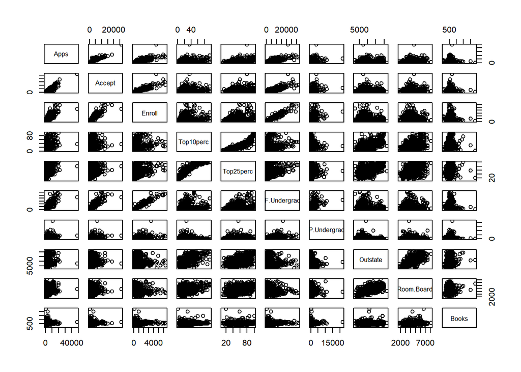

```r
pairs(College[, 3:12])
```

### Utilice la función `plot()` para producir gráficos de caja de lado a lado de Outstate vs Private.

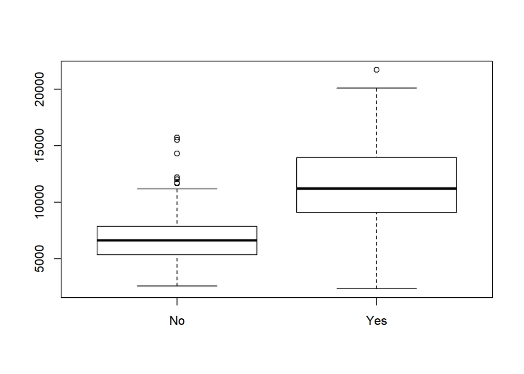

```r
boxplot(College$Outstate ~ College$Private)
```

### Crear una nueva variable cualitativa, llamada “Elite”, para tratar la variable Top10perc.

Vamos a dividir las universidades en dos grupos en función de si o no la proporción de los estudiantes que vienen del 10% superior de su escuela secundaria supera el 50%.

```r
Elite = rep ("No",nrow(College ))
Elite [College$Top10perc >50]="Yes"
Elite = as.factor (Elite)
College = data.frame(College, Elite)
```

```r
summary(Elite)
```

```
##  No Yes
## 699  78
```

### Ahora usa la función `plot()` para producir de lado a lado los diagramas de caja de Outstate vs Elite.

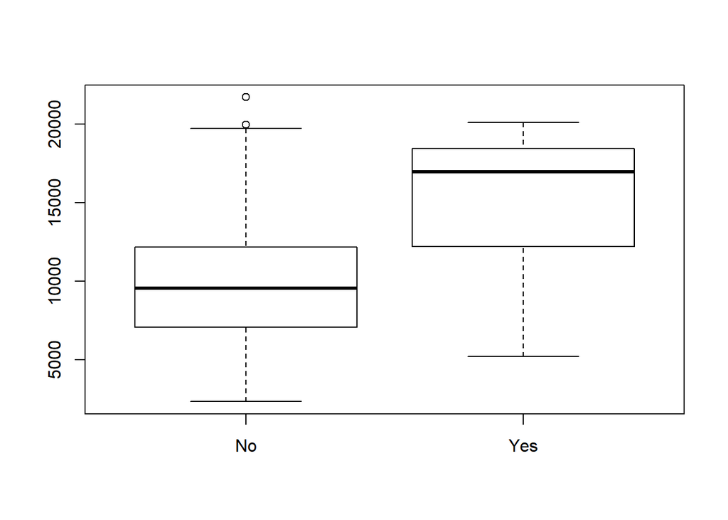

```r
boxplot(College$Outstate ~ College$Elite)
```

Se puede concluir que las universidades de Elite, suelen tener mayor cantidad de estudiantes foraneos.

### Utilizar la función `hist()` para producir algunos histogramas.

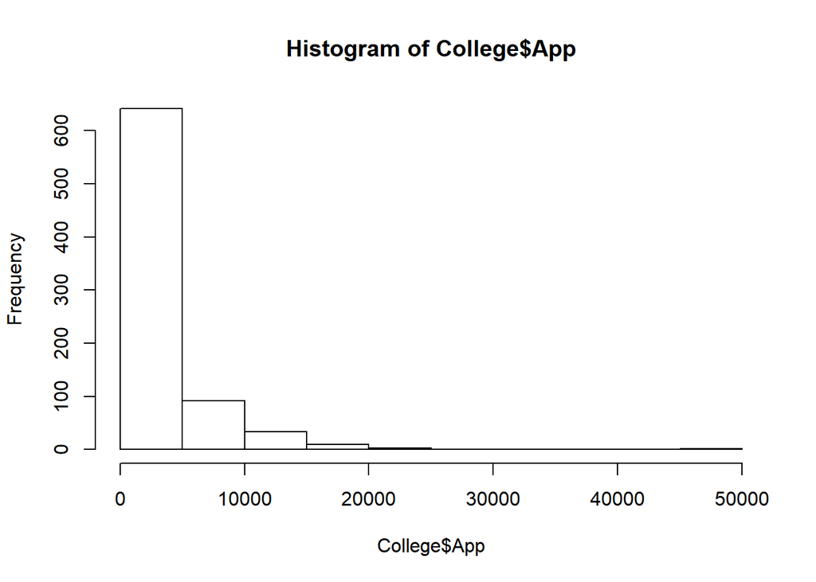

```r
hist(College$App)
```

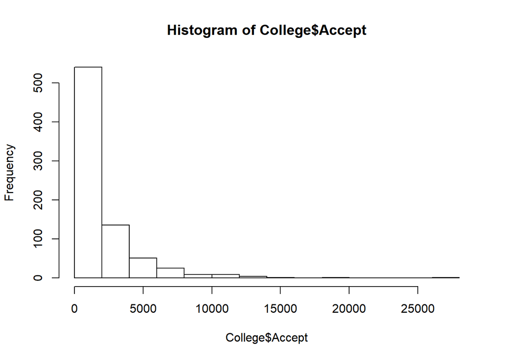

```r
hist(College$Accept)
```

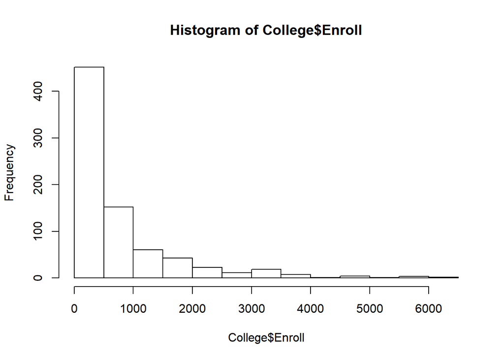

```r
hist(College$Enroll)
```

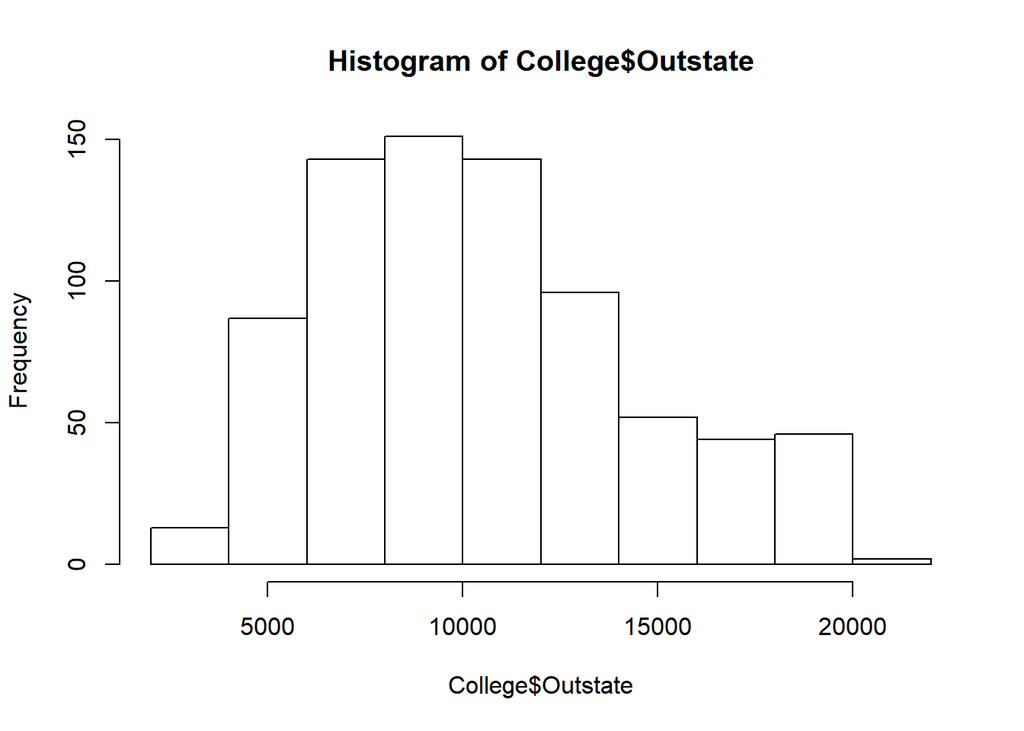

```r
hist(College$Outstate)
```

*Nota:* Como muestro el informe en forma de Notebook, no es necesario realizar la division del area grafica.

### Continuar explorando los datos, y proporcionar un breve resumen de lo que se descubre.

Creare dos DataFrames separados para cada valor de la nueva columna `Elite`. Es esta manera, puedo realizar comparaciones directamente sobre la data. Quiero explorar las diferencias entre las Universidades de elite y las regulares.

```r
College_Elite <- College[College$Elite == 'Yes',]
College_Non_Elite <- College[College$Elite == 'No',]
```

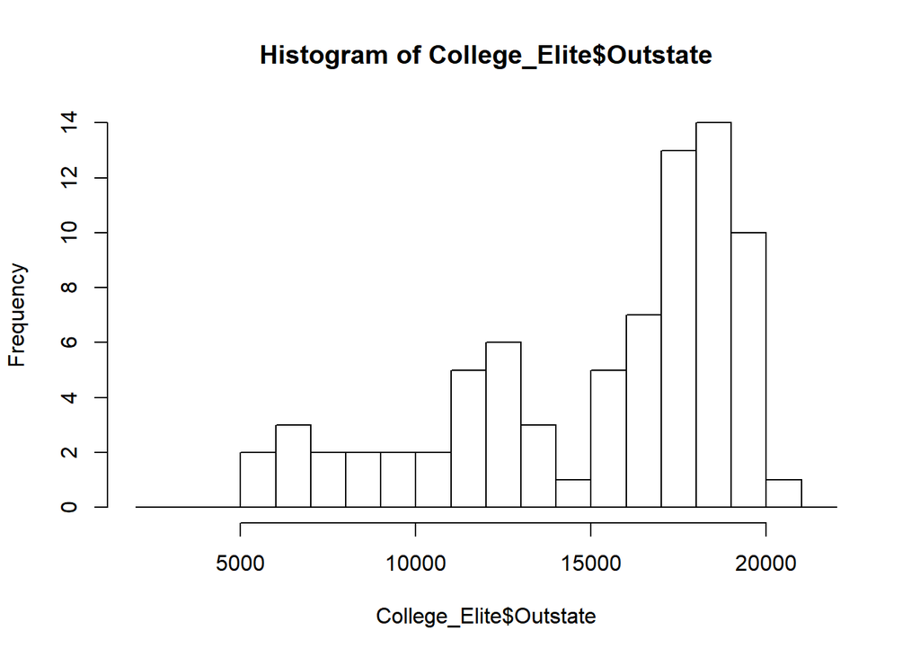

```r
hist(College_Elite$Outstate, xlim=c(2000, 22000), breaks=seq(2000, 22000, 1000))
```

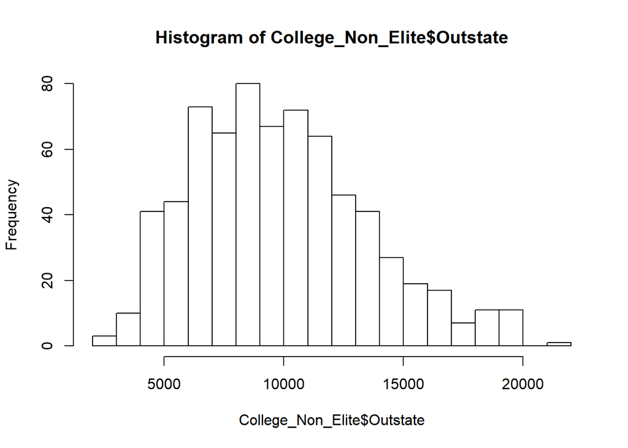

```r
hist(College_Non_Elite$Outstate, xlim=c(2000, 22000), breaks=seq(2000, 22000, 1000))
```

Comparare este valor, con la cantidad de estudiantes aceptados en general:

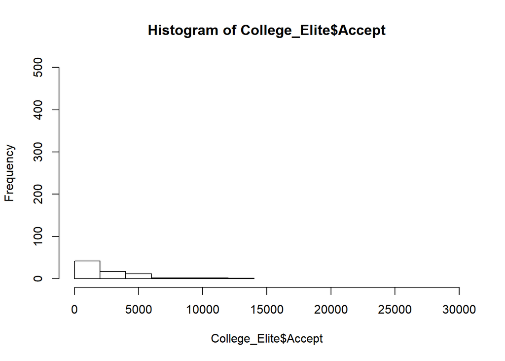

```r
hist(College_Elite$Accept, xlim=c(0, 30000), ylim = c(0, 500))
```

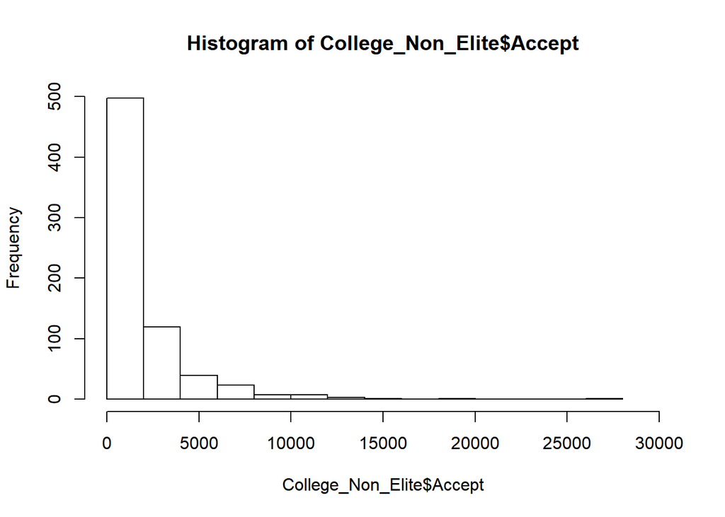

```r
hist(College_Non_Elite$Accept, xlim=c(0, 30000), ylim = c(0, 500))
```